# Visualization with Python - matplotlib ①

## matplotlib ①

#### matplotlib는 python에서 자료를 chart나 plot으로 시각화하는 패키지이다.

> 다음의 plot을 제공한다.
> - 라인 플롯 (line plot)
> - 스캐터 플롯 (scatter plot)
> - 컨투어 플롯 (contour plot)
> - 서피스 플롯 (surface plot)
> - 바 차트 (bar chart)
> - 히스토그램 (histogram)
> - 박스 플롯 (box plot)

#### 시각화 예제는 아래 사이트를 방문하면 볼 수 있다.

> - http://matplotlib.org/gallery.html

### matplotlib.pylab

#### pylab 서브패키지는 MATLAB의 시각화 명령을 거의 그대로 사용할 수 있도록 가져온 것이다.

- 아래와 같이 import하여 사용한다.

```python
import matplotlib as mpl
import matplotlib.pylab as plt
%matplotlib inline
```

### 라인 플롯 (line plot)

#### line plot은 데이터가 시간, 순서 등에 따라 어떻게 변화하는지 확인할 수 있다.

> `plot` 명령어를 사용한다.
> - doc는 아래 사이트를 가서 확인하자.
> - http://matplotlib.org/api/pyplot_api.html#matplotlib.pyplot.plot

#### 만약 데이터가 1, 4, 9, 16 으로 변화하였다면 다음과 같이 `plot` 명령에 데이터 리스트 혹은 `ndarray` 객체를 넘긴다.

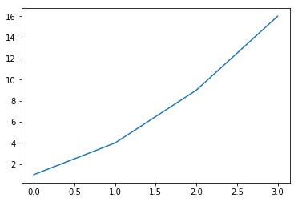

```python
plt.plot([1, 4, 9, 16])
plt.show()
```

#### 이 때, x 축 값(tick)은 자동으로 0, 1, 2, 3 이 된다.

> 만약 xtick 위치를 별도로 명시하고 싶다면 다음과 같이 x값을 추가하면 된다.

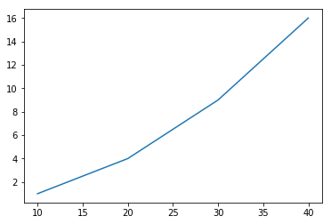

```python
x = [10, 20, 30, 40]
y = [1, 4, 9, 16]
plt.plot(x, y)
plt.show()
```

#### `show` 명령은 시각화 명령을 실제로 차트로 렌더링(rendering)하고 마우스 움직임 등의 이벤트를 기다리라는 지시이다.

> **jupyter notebook에서는 셀 단위로 플롯 명령을 자동 렌더링 해주므로 `show` 명령이 필요없다.**

> 일반 파이썬 인터프리터로 가동되는 경우를 대비하여 **항상 마지막에 실행하도록 한다.**

> `show` 명령을 주면 마지막 **플롯 명령으로부터 반환된 플롯 객체의 표현도 가려주는 효과가 있다.**

### Style

#### `plt.plot( )`은 다양한 Style을 지원한다.

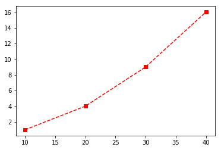

```python
plt.plot(x,y, 'rs--')
plt.show()
```

#### 스타일 문자열은 색깔(color), 마커(marker), 선 종류(line style)의 순서로 지정한다. 만약 지정을 하지 않으면 default값이 적용된다.

- 위의 예는(red, square, --선)이 적용되었다.

### color

- color는 색 이름 혹은 약자를 사용하거나 `#` 문자로 시작되는 **RGB코드를 사용**한다.
- [전체 color 목록](http://matplotlib.org/examples/color/named_colors.html)

| color | 약자 |
| --- | --- |
| `blue` | `b` |
| `green` | `g` |
| `red` | `r` |
| `cyan` | `c` |
| `magenta` | `m` |
| `yellow` | `y` |
| `black` | `k` |
| `white` | `w` |

### marker

| 마커 문자열 | 의미 |
| --- | --- |
| `.` | point marker |
| `,` | pixel marker |
| `o` | circle marker |
| `v` | triangle_down marker |
| `^` | triangle_up marker |
| `<` | triangle_left marker |
| `>` | triangle_right marker |
| `1` | tri_down marker |
| `2` | tri_up marker |
| `3` | tri_left marker |
| `4` | tri_right marker |
| `s` | square marker |
| `p` | pentagon marker |
| `*` | star marker |
| `h` | hexagon1 marker |
| `H` | hexagon2 marker |
| `+` | plus marker |
| `x` | x marker |
| `D` | diamond marker |
| `d` | thin_diamond marker |

### line style

| 선 스타일 문자열 | 의미 |
| --- | --- |
|  | 선을 긋지않고 marker로만 표시 |
| `-` | solid line style |
| `--` | dashed line style |
| `-.` | dash-dot line style |
| `:` | dotted line style |

### 기타 스타일

| 스타일 문자열 | 약자 | 의미 |
| --- | --- | --- |
| `color` | `c` | 선 색깔 |
| `linewidth` | `lw` | 선 굵기 |
| `linestyle` | `ls` | 선 스타일 |
| `marker` |  | 마커 종류 |
| `markersize` | `ms` | 마커 크기 |
| `markeredgecolor` | `mec` | 마커 선 색깔 |
| `markeredgewidth` | `mew` | 마커 선 굵기 |
| `markerfacecolor` | `mfc` | 마커 내부 색깔 |

#### 기타 스타일은 인수 이름을 정확하게 지정해야 한다. `matplotlib.lines.Line2D` 클래스에 대한 아래를 참조하자.

- http://matplotlib.org/api/lines_api.html#matplotlib.lines.Line2D

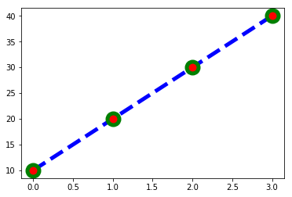

```python
plt.plot(x, c="b", lw=5, ls="--", marker="o", ms=15, mec="g", mew=5, mfc="r")
plt.show()
```

### plot 범위 설정

- `xlim`과 `ylim`을 사용한다.
- x축, y축의 최소값과 최대값을 설정할 수 있다.

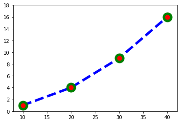

```python
plt.plot(x, y, c="b", lw=5, ls="--", marker="o", ms=15, mec="g", mew=5, mfc="r")
plt.xlim(8, 42)
plt.ylim(0, 18)
plt.show()
```

### tick 설정

- 플롯이나 차트에서 **축상의 위치 표시 지점을 tick**이라고 하고 이 틱에 써진 숫자 혹은 글자를 tick label이라고 한다.

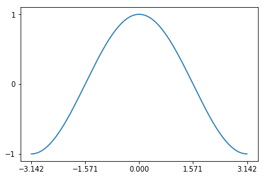

```python
import numpy as np

X = np.linspace(-np.pi, np.pi, 256)
C = np.cos(X)

plt.plot(X, C)

plt.xticks([-np.pi, -np.pi/2, 0, np.pi/2, np.pi])
plt.yticks([-1, 0, +1])
plt.show()
```

#### 다음 예처럼 tick label 문자열에 LaTeX을 활용 할 수 있다.

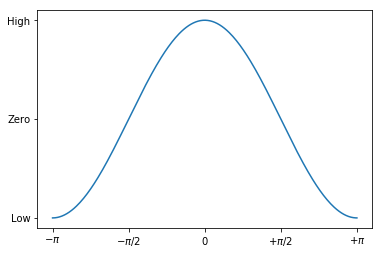

```python
X = np.linspace(-np.pi, np.pi, 256)
C = np.cos(X)
plt.plot(X, C)
plt.xticks([-np.pi, -np.pi/2, 0, np.pi/2, np.pi], [r'$-\pi$', r'$-\pi/2$', r'$0$', r'$+\pi/2$', r'$+\pi$'])
plt.yticks([-1, 0, 1], ["Low", "Zero", "High"])
plt.show()
```

### grid 설정

- 좌표나 tick의 위치를 잘 알아보기 위해 그림에 grid(격자)를 표현할 수 있다.
- `grid(False)`, `grid(True)`를 통해 grid 사용 여부를 설정할 수 있다.

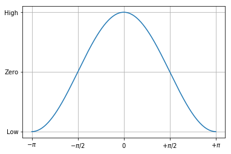

```python
X = np.linspace(-np.pi, np.pi, 256)
C = np.cos(X)
plt.plot(X, C)
plt.xticks([-np.pi, -np.pi/2, 0, np.pi/2, np.pi], [r'$-\pi$', r'$-\pi/2$', r'$0$', r'$+\pi/2$', r'$+\pi$'])
plt.yticks([-1, 0, 1], ["Low", "Zero", "High"])
plt.grid(True)
plt.show()
```

### multi line plot

- x 데이터, y 데이터, 스타일 문자열을 반복하여 인수로 넘긴다.
- 이 경우에는 하나의 선을 그릴 때처럼 인수들을 생략하면 안된다.

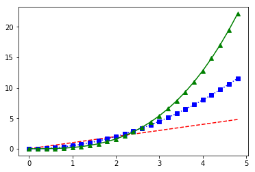

```python
t = np.arange(0., 5., 0.2)
plt.plot(t, t, 'r--', t, 0.5*t**2, 'bs:', t, 0.2*t**3, 'g^-')
plt.show()
```

### Hold

> 하나의 `plot` 명령이 아니라 복수의 `plot` 명령을 하나의 그림에 겹쳐서 그릴 수도 있다.

> matplotlib 1.5까지는 `hold(True)` 명령을 이용하여 기존의 그림 위에 겹쳐 그리도록 하였다. 겹치기를 종료하는 것은 `hold(False)` 명령이다.

> **matplotlib 2.0부터는 모든 플롯 명령에 `hold(True)`가 자동 적용**

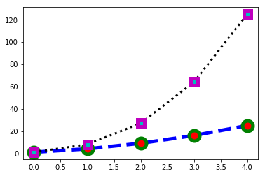

```python
x_1 = [1, 4, 9, 16, 25]

x_2 = [1, 8, 27, 64, 125]

plt.plot(x_1, c="b", lw=5, ls="--", marker="o", ms=15, mec="g", mew=5, mfc="r")
# plt.hold(True)   # <- 1,5 버전에서는 이 코드가 필요하다.
plt.plot(x_2, c="k", lw=3, ls=":", marker="s", ms=10, mec="m", mew=5, mfc="c")
# plt.hold(False)  # <- 1,5 버전에서는 이 코드가 필요하다.
plt.show()
```

### legend

> 여러 개의 라인 플롯을 동시에 그리는 경우, 범례(legend)를 추가해야 시각화가 효율적이다.

| loc 문자열 | 숫자 |
| --- | --- |
| `best` | 0 |
| `upper right` | 1 |
| `upper left` | 2 |
| `lower left` | 3 |
| `lower right` | 4 |
| `right` | 5 |
| `center left` | 6 |
| `center right` | 7 |
| `lower center` | 8 |
| `upper center` | 9 |
| `center` | 10 |

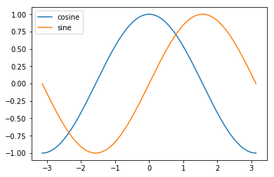

```python
X = np.linspace(-np.pi, np.pi, 256)
C, S = np.cos(X), np.sin(X)
plt.plot(X, C, label="cosine")
plt.plot(X, S, label="sine")
plt.legend(loc=2)
plt.show()
```

### 축 lable, title

- `xlabel`, `ylabel`, `title`을 사용하여 plot의 가독성을 높일 수 있다.

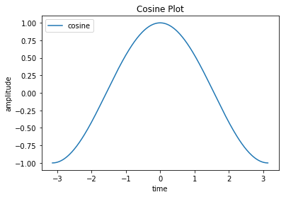

```python
X = np.linspace(-np.pi, np.pi, 256)
C, S = np.cos(X), np.sin(X)
plt.plot(X, C, label="cosine")
plt.xlabel("time")
plt.ylabel("amplitude")
plt.title("Cosine Plot")
plt.legend(loc=2)
plt.show()
```

### 특정 부분을 강조

`annotate`을 사용하면 그림 내에 화살표를 포함한 부가 설명을 넣을 수 있다.

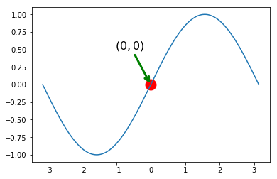

```python
plt.plot(X, S, label="sine")
plt.scatter([0], [0], color="r", linewidth=10)
plt.annotate(r'$(0,0)$', xy=(0, 0), xycoords='data', xytext=(-50, 50),
             textcoords='offset points', fontsize=16,
             arrowprops=dict(arrowstyle="->", linewidth=3, color="g"))
plt.show()
```

### matplotlib plot의 구조

- 아래 그림처럼 Figure, Axes, Axis 등으로 구성

[figure not shown]

### figure

- 모든 그림은 Figure 라고 하는 부르는 `matplotlib.figure.Figure` 클래스 객체에 포함되어 있다.
- inline plot이 아닌 경우에는 하나의 Figure는 하나의 아이디 숫자와 윈도우(Window)를 가진다.

[Figure'doc](http://matplotlib.org/api/figure_api.html#matplotlib.figure.Figure)

- 원래 Figure를 생성하려면 `figure`를 사용하여 그 반환값으로 Figure 객체를 얻어야 한다.
  > - 그러나 일반적인 `plot`을 실행하면 자동으로 Figure를 생성해주기 때문에 일반적으로는 `figure` 명령을 잘 사용하지 않는다.
  > - `figure` 명령을 명시적으로 사용하는 경우는 여러개의 윈도우를 동시에 띄워야 하거나(line plot이 아닌 경우)
  > - Jupyter 노트북 등에서(line plot의 경우) **그림의 크기를 설정하고 싶을 때**이다. 그림의 크기는 figsize 인수로 설정한다.

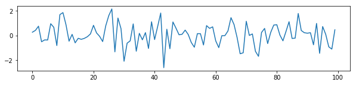

```python
f1 = plt.figure(figsize=(10, 2))
plt.plot(np.random.randn(100))
plt.show()
```

#### 만약 명시적으로 `figure` 명령을 사용하지 않은 경우에 Figure 객체를 얻으려면 `gcf` 명령을 사용한다.

> `Get a reference to the current figure.`의 약어

> f1의 figure값을 동일하게 가져온다.

```
Figure(720x144) 4567337504
Figure(720x144) 4567337504
```

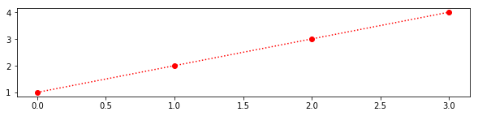

```python
f1 = plt.figure(figsize=(10, 2))
plt.plot([1, 2, 3, 4], 'ro:')
f2 = plt.gcf()
print(f1, id(f1))
print(f2, id(f2))
plt.show()
```

### Axes와 Subplot

- 하나의 윈도우(Figure)안에 여러 개의 plot을 배열 형태로 보여야하는 경우도 있다.
- Figure 안에 있는 각각의 플롯은 Axes라고 불리는 객체에 속한다.

[Axes'docs](http://matplotlib.org/api/axes_api.html#matplotlib.axes.Axes)

#### Figure 안에 Axes를 생성하려면 원래는 `subplot` 을 사용하여 명시적으로 Axes 객체를 얻어야 한다.

> 그러나 `plot`을 바로 사용해도 자동으로 Axes를 생성해 준다.

#### `subplot` 명령은 그리드(grid) 형태의 Axes 객체들을 생성하는데 Figure가 행렬(matrix)이고 Axes가 행렬의 원소라고 생각하면 된다.

> 예를 들어 위와 아래 두 개의 플롯이 있는 경우 행이 2 이고 열이 1인 2x1 행렬이다.

> `subplot`은 세 개의 인수를 가지는데 처음 두개의 원소가 전체 그리드 행렬의 shape이고 세번째 인수는 행렬 원소의 위치라고 생각하면 된다.

```
Axes(0.125,0.536818;0.775x0.343182)
Axes(0.125,0.125;0.775x0.343182)
```

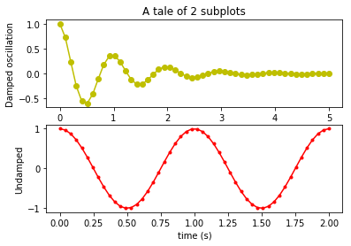

```python
x1 = np.linspace(0.0, 5.0)
x2 = np.linspace(0.0, 2.0)
y1 = np.cos(2 * np.pi * x1) * np.exp(-x1)
y2 = np.cos(2 * np.pi * x2)

ax1 = plt.subplot(2, 1, 1)
plt.plot(x1, y1, 'yo-')
plt.title('A tale of 2 subplots')
plt.ylabel('Damped oscillation')
print(ax1)

ax2 = plt.subplot(2, 1, 2)
plt.plot(x2, y2, 'r.-')
plt.xlabel('time (s)')
plt.ylabel('Undamped')
print(ax2)

plt.show()
```

#### 만약 `2x2` 형태의 네 개의 플롯이라면 다음과 같이 그린다. 이 때 `subplot` 의 인수는 `(2,2,1)`를 줄여서 221 라는 하나의 숫자로 표시할 수도 있다.

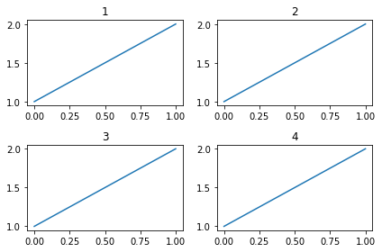

```python
plt.subplot(221); plt.plot([1, 2]); plt.title(1)
plt.subplot(222); plt.plot([1, 2]); plt.title(2)
plt.subplot(223); plt.plot([1, 2]); plt.title(3)
plt.subplot(224); plt.plot([1, 2]); plt.title(4)
plt.tight_layout()
plt.show()
```

### Axis

- `axis([xmin, xmax, ymin, ymax])`
- `axis('off')`
- `axis('equal')`
- `axis('scaled')`
- `axis('tight')`

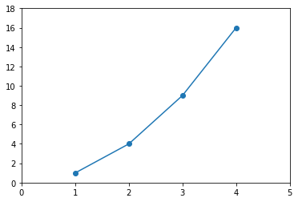

```python
# axis([xmin, xmax, ymin, ymax])
plt.plot([1,2,3,4], [1,4,9,16], '-o')
plt.axis([0, 5, 0, 18])
plt.show()
```

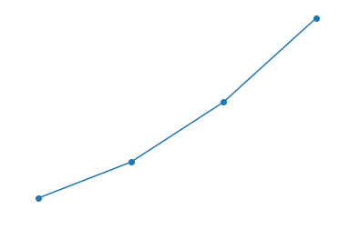

```python
# axis('off')
plt.plot([1,2,3,4], [1,4,9,16], '-o')
plt.axis('off')
plt.show()
```

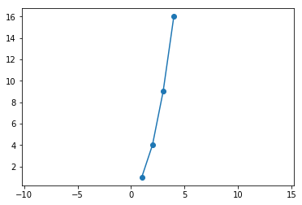

```python
# axis('equal') x축, y축 같게
plt.plot([1,2,3,4], [1,4,9,16], '-o')
plt.axis('equal')
plt.show()
```

```python
# axis('scaled'), 보이는 부분만 잘라서
plt.plot([1,2,3,4], [1,4,9,16], '-o')
plt.axis('scaled')
plt.show()
```

[output not shown]

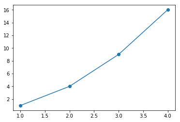

```python
# axis('tight'), 축을 plot에 타이트하게 붙여 잘 보이게
plt.plot([1,2,3,4], [1,4,9,16], '-o')
plt.axis('tight')
plt.show()
```

### Style에 변화를 줄 수도 있다.

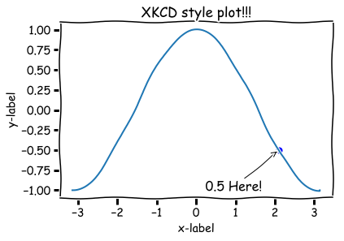

```python
## xkcd 스타일
with plt.xkcd():
    plt.title('XKCD style plot!!!')
    plt.plot(X, C, label="cosine")
    t = 2 * np.pi / 3
    plt.scatter(t, np.cos(t), 50, color='blue')
    plt.xlabel("x-label")
    plt.ylabel("y-label")
    plt.annotate(r'0.5 Here!', xy=(t, np.cos(t)), xycoords='data', xytext=(-90, -50),
                 textcoords='offset points', fontsize=16, arrowprops=dict(arrowstyle="->"))
plt.show()
```

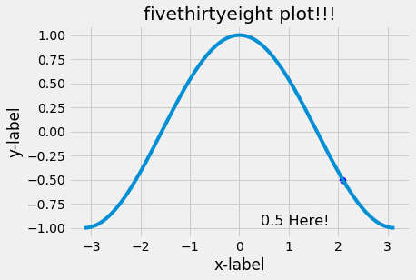

```python
## fivethirtyeight 스타일
with plt.style.context('fivethirtyeight'):
    plt.title('fivethirtyeight plot!!!')
    plt.plot(X, C, label="cosine")
    t = 2 * np.pi / 3
    plt.scatter(t, np.cos(t), 50, color='blue')
    plt.xlabel("x-label")
    plt.ylabel("y-label")
    plt.annotate(r'0.5 Here!', xy=(t, np.cos(t)), xycoords='data', xytext=(-90, -50),
                 textcoords='offset points', fontsize=16, arrowprops=dict(arrowstyle="->"))
plt.show()
```

### 한글 설정

- matplotlib에서 한글을 사용하려면 다음과 같이 한글 폰트를 적용해야 한다.
- 여기에서는 AppleGothic 폰트를 사용하였다.

#### 설치된 폰트를 사용하는 방법은 크게 두가지 이다.

- rc parameter 설정으로 이후의 그림 전체에 적용
- 인수를 사용하여 개별 텍스트 관련 명령에만 적용
- 한글 문자열은 항상 유니코드를 사용해야 한다.

```python
mpl.rc('font', family='AppleGothic')
mpl.rc('axes', unicode_minus=False)
```

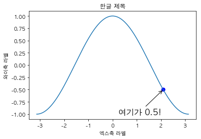

```python
plt.title(u'한글 제목')
plt.plot(X, C, label=u"코사인")
t = 2 * np.pi / 3
plt.scatter(t, np.cos(t), 50, color='blue')
plt.xlabel(u"엑스축 라벨")
plt.ylabel(u"와이축 라벨")
plt.annotate(u"여기가 0.5!", xy=(t, np.cos(t)), xycoords='data', xytext=(-90, -50),
             textcoords='offset points', fontsize=16, arrowprops=dict(arrowstyle="->"))
plt.show()
```

#### 만약 개별적으로 폰트를 적용하고 싶을 때는 다음과 같이 폰트 패밀리, 색상, 크기를 정하여 플롯 명령의 `fontdict` 인수에 넣는다.

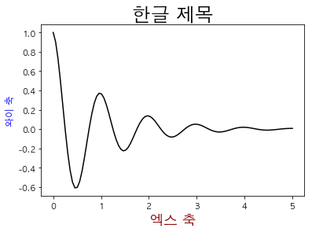

```python
font1 = {'family': 'AppleGothic', 'color':  'black', 'size': 24}
font2 = {'family': 'AppleGothic', 'color':  'darkred', 'weight': 'normal', 'size': 18}
font3 = {'family': 'AppleGothic', 'color':  'blue', 'weight': 'light', 'size': 12}

x = np.linspace(0.0, 5.0, 100)
y = np.cos(2*np.pi*x) * np.exp(-x)

plt.plot(x, y, 'k')
plt.title(u'한글 제목', fontdict=font1)
plt.xlabel(u'엑스 축', fontdict=font2)
plt.ylabel(u'와이 축', fontdict=font3)
plt.subplots_adjust()
plt.show()
```